# 09. Воспроизведение Lind & Lotterhos 2025 на ADAPTOGENE — их дизайн, их метрика

14 реплик MVP · сады общего сада · tau Кендалла · 4 из 5 их реализаций offset

## Обзор

```bash
if [ ! -f /mnt/data/eugene/ADAPTOGENE/work/journal/diagrams/09_00_abstract.svg ] || \
   [ /mnt/data/eugene/ADAPTOGENE/work/journal/diagrams/09_00_abstract.d2 -nt \
     /mnt/data/eugene/ADAPTOGENE/work/journal/diagrams/09_00_abstract.svg ]; then
  d2 --theme 200 --layout elk \
    /mnt/data/eugene/ADAPTOGENE/work/journal/diagrams/09_00_abstract.d2 \
    /mnt/data/eugene/ADAPTOGENE/work/journal/diagrams/09_00_abstract.svg
fi
```

[figure not shown]

# Часть I. Дизайн, который здесь не наш

## 1. Что именно взято из публикации и её кода

Журнал 08 отвечал на вопрос «какой набор SNP подавать в модель offset» метриками, которые я определил сам (ρ Спирмена против падения приспособленности, ΔR² сверх евклидова нуля). Эти числа самодостаточны, но **не сравнимы ни с чем опубликованным**.

Lind & Lotterhos 2025 (*Mol Ecol Resour* 25(4):e14008, doi:10.1111/1755-0998.14008; код `ModelValidationProgram/MVP-offsets`) прогнали тот же вопрос на **4.85 млн** оценок и на симуляциях **того же депозита**, из которого взяты наши 14 реплик. Поэтому здесь их дизайн и метрика берутся дословно, а наши числа ставятся рядом с опубликованными. **Ни одна метрика в этом журнале не изобретена нами.**

Что именно прочитано из их кода, а не додумано:

- **Сады.** «Full factorial in silico reciprocal transplant design», **100** садов внутри ландшафта (климат каждого дема — сад). Плюс сады климатической новизны: в `02_analysis/04_outlier_climate_runs/06_multivariate_calculate_climate_outlier_fitness.ipynb` стоит `deviations = [0, 1.72, 2.35, 2.74, 3.13, 3.53, 3.92, 4.31, 4.70, 5.09, 5.48, 5.88]` и `outlier_vals[dev][env] = envdata[env].mean() + (dev * np.std(envdata[env]))`, причём цикл идёт `for env in envs` — то есть **обе** оси среды двигаются одновременно, а отклонение **0** (сам центр климата) included. Итого **12** садов новизны, а не 11.
- **Приспособленность.** `MVP_climate_outlier_fitness_calculator.R`: `fits = dmvnorm(phenos, opts, sigma = fitness_varcov) / fitness_norm`, затем `fitness[1, transplant_ID] = mean(fits)` — **арифметическое среднее по особям** популяции (журнал 08 усреднял логарифм; здесь усредняется приспособленность, как у них).
- **Метрика.** `01_src/MVP_03_validate_gradient_forests.py::calculate_performance`: `garden_performance` = `offset.corrwith(fitness, axis=1, method='kendall')` — одна **tau Кендалла на сад**, по 100 популяциям-источникам; `source_performance` — одна tau на популяцию-источник по садам. Знак их: приспособленность падает с ростом offset, поэтому **хорошая модель даёт отрицательную tau**.
- **Панели маркеров.** `marker_sets = ['all', 'adaptive', 'neutral']`.

[output not shown]

## 2. Сады и проверка, что это их величина

**Скрипт:** `benchmarks/mvp_garden_fitness.R`. На реплику строится матрица **112 садов × 100 популяций-источников**: 100 садов ландшафта + 12 садов новизны. Приспособленность берётся из тождества журнала 08 (`log f = b1·d1² + b2·d2²`, посидовые коэффициенты, R² = 1.000000), поэтому никакого распределительного допущения этот скрипт не вносит — он применяет функцию самой реплики к новому оптимуму.

**Проверка, а не декларация.** Разность «симпатрическая минус аллопатрическая приспособленность» обязана воспроизвести колонку `final_LA` самого депозита. Если бы матрица садов считала не ту величину, эта проверка сломалась бы.

```r
check_files(c(
  "скрипт садов"       = "/mnt/data/eugene/ADAPTOGENE/benchmarks/mvp_garden_fitness.R",
  "QC садов"           = paste0(R9, "garden_qc.tsv"),
  "матрица (пример)"   = paste0(R9, "garden_fitness_1232548.tsv")
))
```

```
## [OK] скрипт садов
## [OK] QC садов
## [OK] матрица (пример)
```

```bash
# НЕ ПЕРЕЗАПУСКАТЬ — выполнено 2026-08-05
nix shell nixpkgs#docker-client -c docker run --rm --user $(id -u):$(id -g) \
  -e USER=adaptogene -e OPENBLAS_NUM_THREADS=4 \
  -v /mnt/data/eugene/ADAPTOGENE:/pipeline adaptogene:latest \
  Rscript /pipeline/benchmarks/mvp_garden_fitness.R
```

```
##        seed n_gardens n_landscape n_novelty LA_ours LA_deposit LA_diff
##      <char>     <int>       <int>     <int>   <num>      <num>   <num>
##  1: 1232568       112         100        12  0.5113     0.4895  0.0218
##  2: 1231578       112         100        12  0.3400     0.3316  0.0084
##  3: 1231288       112         100        12  0.3996     0.3917  0.0079
##  4: 1232578       112         100        12  0.5563     0.5488  0.0075
##  5: 1232548       112         100        12  0.5531     0.5458  0.0073
##  6: 1231858       112         100        12  0.4763     0.4728  0.0035
##  7: 1232218       112         100        12  0.3726     0.3674  0.0052
##  8: 1231993       112         100        12  0.3822     0.3667  0.0155
##  9: 1232398       112         100        12  0.5565     0.5462  0.0103
## 10: 1233208       112         100        12  0.4742     0.4674  0.0068
## 11: 1232923       112         100        12  0.5653     0.5539  0.0114
## 12: 1231798       112         100        12  0.5593     0.5459  0.0134
## 13: 1232908       112         100        12  0.4857     0.4766  0.0091
```

[output cut: 17 more lines]

- Садов на реплику: **112** (**100** ландшафтных + **12** новизны)
- Популяций-источников: **100**, особей на популяцию: **10**
- Локальная адаптация, наша минус депозитная: **+0.0035 … +0.0218** на всех 14 репликах
- Медианный ранг родного сада для своей популяции: **2 … 7** из 100
- Файлы: `garden_fitness_{seed}.tsv` (14 шт.), `gardens_{seed}.tsv`, `garden_qc.tsv`

Расхождение с `final_LA` депозита не превышает **0.022** при значениях **0.33 … 0.55**, то есть **0.7 … 4%**. Матрица садов — это их величина, а не наша реконструкция, и всё, что дальше считается на ней, сравнимо с их числами. Родной сад не всегда ранг 1 — демы стоят на сетке 10×10 с шагом 0.2°, у соседей почти тот же оптимум, поэтому ранги 2–7 из 100 ожидаемы.

## 3. Панели маркеров: их три термина плюс наша ось

**Скрипт:** `benchmarks/mvp_build_snp_sets.R`. Их сравнение оперирует тремя панелями, и отображение на наши наборы — **не** совпадение по названию, а совпадение по определению (Методы Lind & Lotterhos 2025):

| их термин | определение в их Методах | наш набор |
| --- | --- | --- |
| `adaptive` | «SNPs at QTNs with effects on >= 1 trait», среднее **188** локусов | `truth` — **оракул**, каузальные локусы |
| `neutral` | «SNPs on linkage groups without any QTNs», среднее **16 520** | `neutral_all` |
| `all` | все маркеры, среднее **33 169** | `all` |

**Их `adaptive` — это истина, а не результат GEA-скана.** Это оракульная панель, недоступная на реальных данных. Поэтому их утверждение «выигрыш от adaptive < 3%» читается как «даже знание истинных каузальных локусов почти не помогает», а вовсе не как «отбор SNP по ассоциации бесполезен».

**Наша `neutral_all` — их определение дословно.** `convert_mvp.R:464` присваивает категорию `background_neutral` локусам на LG **11–20**, то есть на группах сцепления без QTN, цитируя при этом Методы источника. Никакой подгонки: категория была построена в журнале 04 до того, как этот вопрос возник.

**Наша собственная ось — панели, полученные GEA-сканом**, которых в их дизайне нет вообще. Три точки на шкале «полнота — точность», все три с помодельными рабочими точками схемы S1 (`benchmarks/mvp_anchor_schemes.tsv`, перенос без переизбора по истине):

| наш набор | правило | размер | каузальных внутри |
| --- | --- | --- | --- |
| `union` | любой из LFMM/RDA/EMMAX | **217 … 260** | 4 … 30 |
| `best` | согласие **>= 2** из 3, окно 5 кб | **121 … 177** | 3 … 24 |
| `intersect3` | согласие **всех 3** | **3 … 97** | 0 … 6 |
| `rand_best1` | розыгрыш из `background_neutral` размера `best` | **121 … 177** | 0 |

`rand_best1` остаётся **нашим** полом: он единственный отделяет размер набора от его качества, чего их дизайн сделать не может (их `neutral` в 100 раз больше их `adaptive`).

```r
check_files(c(
  "скрипт наборов" = "/mnt/data/eugene/ADAPTOGENE/benchmarks/mvp_build_snp_sets.R",
  "сводка наборов" = paste0(R8, "snp_sets_summary.tsv")
))
```

```
## [OK] скрипт наборов
## [OK] сводка наборов
```

```
## Размер панелей (число SNP):
##
## Key: <seed>
##        seed   all  best intersect3 neutral_all rand_best1 truth union
##      <char> <int> <int>      <int>       <int>      <int> <int> <int>
##  1: 1231288 11194   121         72        5674        121     6   218
##  2: 1231578 13054   141         29        6195        141   515   218
##  3: 1231798  9867   160         15        4733        160   395   231
##  4: 1231858  8482   166          7        4306        166    46   240
##  5: 1231993  4975   158         45        2419        158     8   218
##  6: 1232218  9882   139         67        4909        139     6   219
##  7: 1232398  9498   154         97        4830        154    10   218
##  8: 1232548 10325   156          5        5048        156    70   217
##  9: 1232568 10019   165         61        4957        165    38   219
## 10: 1232578 10072   175         21        5020        175    28   260
## 11: 1232908 11353   149          6        5662        149   268   225
## 12: 1232923 12095   173          3        5734        173   363   236
## 13: 1233133 10756   164         11        5267        164   324   235
## 14: 1233208  9627   177         15        4915        177    39   218
```

- Панелей на реплику: **7** (3 их + 3 наши GEA + наш пол)
- `all` **4 975 … 13 054** · `neutral_all` **2 419 … 6 195** · `truth` **6 … 515**
- `union` **217 … 260** · `best` **121 … 177** · `intersect3` **3 … 97**

## 4. Методы: 4 из 5 их реализаций, и почему не 5

Они сравнивают пять реализаций четырёх методов: `GFoffset`, `RDA-uncorrected`, `RDA-corrected`, `LFMM2offset`, `RONA`. Отображение на пайплайн:

| их реализация | ADAPTOGENE |
| --- | --- |
| GFoffset | `gradient_forest` (`ntree` 500, `cor_threshold` 0.5, nospatial) |
| LFMM2offset | `geometric_offset` (`LEA::genetic.gap`, `k` = `sNMF.k_best` реплики) |
| RDA-uncorrected | `rda_offset`, `condition_pcs: 0` |
| RDA-corrected | `rda_offset`, `condition_pcs: k_best` — **отдельный проход**, см. ниже |
| RONA | **не реализована в пайплайне** — заявлена как пробел, а не тихо опущена |

`axes: 2` вместо `auto`: измерено на всех **126** прогонах RDA журнала 08 — `rda_axes_used = 2` в **100%** случаев (два предиктора → K_max = 2), поэтому фиксация не меняет ни одного результата и снимает 999 перестановок с каждого сада.

# Часть II. Прогон

## 5. Сад как таблица будущего климата

**Скрипты:** `benchmarks/mvp_write_garden_configs.R` (два конфига на реплику) и `benchmarks/mvp_garden_run.sh` (драйвер).

Сад реализуется так: в таблицу будущего климата пишется **один и тот же** оптимум сада для всех демов, и тогда посайтовый offset пайплайна — это ровно offset(источник *i* → сад *g*).

1. **`future_table` приходит в `stage_custom_climate_future` параметром, а не входом.** Snakemake не видит смены сценария и отвечает «Nothing to be done» — проверено. Поэтому каждый сад запускается с `-R stage_custom_climate_future`. Побочная польза: модели Gradient Forest пересобирать не нужно, они зависят от **настоящего** климата и набора SNP, поэтому строятся один раз на (реплику, набор) и переиспользуются всеми садами.
2. **Пути выходов не различают сценарии.** Все offset пишутся в `Maladaptation/tables/{method}/{set}_{spatial}/`, поэтому следующий сад затирает предыдущий — драйвер **собирает** `genetic_offset_site.tsv` в `offset09/gardens/{seed}/{garden}/` сразу после каждого сада.

```r
check_files(c(
  "генератор конфигов" = "/mnt/data/eugene/ADAPTOGENE/benchmarks/mvp_write_garden_configs.R",
  "драйвер"            = "/mnt/data/eugene/ADAPTOGENE/benchmarks/mvp_garden_run.sh",
  "конфиг прохода A"   = "/mnt/data/eugene/ADAPTOGENE/config_MVP1232548_g.yaml",
  "конфиг прохода B"   = "/mnt/data/eugene/ADAPTOGENE/config_MVP1232548_grdac.yaml"
))
```

```
## [OK] генератор конфигов
## [OK] драйвер
## [OK] конфиг прохода A
## [OK] конфиг прохода B
```

```r
gd <- list.dirs(paste0(R9, "gardens"), recursive = TRUE)
cat("Собрано садов (директорий):", sum(grepl("gardens/[0-9]+/[^/]+$", gd)), "\n")
```

```
## Собрано садов (директорий): 886
```

```bash
# НЕ ПЕРЕЗАПУСКАТЬ — выполнено 2026-08-05
nix shell nixpkgs#docker-client -c docker run --rm --user $(id -u):$(id -g) \
  -e USER=adaptogene -v /mnt/data/eugene/ADAPTOGENE:/pipeline adaptogene:latest \
  Rscript /pipeline/benchmarks/mvp_write_garden_configs.R

# фаза 1: 30 ландшафтных садов (каждый 3-й дем) + все 12 садов новизны, 14 линий параллельно
LIST=$(cat /mnt/data/eugene/ADAPTOGENE/benchmarks/mvp_eval/offset09/garden_subset_phase1.txt)
/mnt/data/eugene/ADAPTOGENE/benchmarks/mvp_garden_run.sh all 14 8 "$LIST"
```

## 6. Стоимость: измеренная, а не оценённая

- Разовая подгонка Gradient Forest на панели `all` (**~10 тыс. SNP**): **3105 с** на реплику, один раз на (реплику, набор), дальше переиспользуется всеми садами
- Устойчивое время одного сада: **660 … 950 с** (≈ **11 мин**), два прохода RDA включительно
- Пик RSS контейнера: **2.9 ГБ** при лимите **40 ГБ**; хост держался в пределах **660 ГБ** при потолке **900 ГБ**
- Разбивка по правилам за 8 садов одной линии: `rda_offset` **67 мин**, `plot_gf_offset_piemap(_points)` **43 мин**, `gradient_forest_offset` **18 мин**, `geometric_offset` **5 мин**

## 6a. Модели строятся один раз на реплику, а не один раз на дорожку

**Ошибка, которая стоила дороже всего, и её механика.** Модель Gradient Forest зависит от **настоящего** климата и панели SNP — от сада она не зависит вообще, потому что сад меняет только будущую среду. Значит, одна модель на пару (реплика, панель) обслуживает все 42 сада.

**Правило, которое отсюда следует:** любая новая панель требует однократной сборки моделей в базовых деревьях с большим лимитом памяти **до** запуска дорожек. Проверка перед прогоном — `ls MVP*_results/_intermediate/gradient_forest/*/adaptive_model.qs` должен покрывать все (реплика × панель).

```r
mods <- Sys.glob("/mnt/data/eugene/ADAPTOGENE/MVP*_results/_intermediate/gradient_forest/*/adaptive_model.qs")
mods <- grep("p[0-9]_results", mods, invert = TRUE, value = TRUE)   # базовые деревья, не клоны
cat("Моделей в базовых деревьях:", length(mods), "\n")
```

```
## Моделей в базовых деревьях: 146
```

```r
cat("Суммарный размер, ГБ:", round(sum(file.size(mods)) / 2^30, 1), "\n")
```

```
## Суммарный размер, ГБ: 33.6
```

# Часть III. Результаты

**Область этой версии файла — 11 реплик из 12 нештрафных**, по **42** сада каждая (30 ландшафтных + 12 садов новизны), 7 панелей, 4 реализации. Реплика **1231288** и оба контроля `Est-Clines` (**1231578**, **1232568**) досчитываются: их панели `all` и `neutral_all` — самые крупные в наборе (до **13 054** и **6 195** SNP), и подгонка Gradient Forest на них не влезала в лимит памяти дорожки. Модели для них пересобраны отдельно (см. раздел 6a), дорожки перезапущены. Ни одно утверждение разделов 7–12 от контролей не зависит: они исключены из всех агрегатов по построению.

## 7. Против опубликованных чисел

```
##                                            quantity published
##                                              <char>    <char>
## 1:                   tau at LA ~ 0.5 (best methods)      -0.6
## 2:                   tau at LA ~ 0.3 (best methods)      -0.2
## 3: median performance gain, adaptive vs all/neutral      < 3%
## 4:         % of models where adaptive beats neutral       68%
## 5:             % of models where adaptive beats all       67%
## 6:              % of models where all beats neutral       74%
##                        ours
##                      <char>
## 1: -0.819 (RDA-uncorrected)
## 2:   -0.688 (RDA-corrected)
## 3:             10.3% / 8.6%
## 4:                    83.3%
## 5:                    81.9%
## 6:                    72.5%
```

## 8. Панели, полученные GEA-сканом: ось, которой нет в их дизайне

```
##              panel      reference n_models pct_panel_wins median_gain_pct
##             <char>         <char>    <int>          <num>           <num>
##  1:      gea_union       adaptive     1440           16.0            -6.0
##  2:      gea_union            all     1440           60.3             1.4
##  3:      gea_union        neutral     1440           66.8             2.8
##  4:      gea_union random_matched     1440           68.8             4.2
##  5:       gea_best       adaptive     1440           26.6            -3.7
##  6:       gea_best            all     1440           53.5             1.0
##  7:       gea_best        neutral     1440           56.7             2.1
##  8:       gea_best random_matched     1440           59.0             4.0
##  9:     gea_strict       adaptive     1440           31.8            -3.3
## 10:     gea_strict            all     1440           50.8             0.7
## 11:     gea_strict        neutral     1440           51.6             1.2
## 12:     gea_strict random_matched     1440           55.4             3.0
## 13: random_matched       adaptive     1440           12.8           -10.0
## 14: random_matched            all     1440           23.5            -2.0
## 15: random_matched        neutral     1440           38.3            -0.4
```

Медиана tau по ландшафтным садам (GF / LFMM2 / RDA-uncorrected):

- `truth` (оракул) **−0.773 / −0.780 / −0.778**
- `gea_best` (>= 2 из 3) **−0.745 / −0.747 / −0.742**
- `gea_union` (полнота) **−0.696 / −0.744 / −0.713**
- `gea_strict` (точность) **−0.676 / −0.702 / −0.611**
- `all` **−0.687 / −0.697 / −0.645**
- `neutral` **−0.678 / −0.681 / −0.622**
- `rand_best1` (пол) **−0.675 / −0.676 / −0.617**

**Панель, полученная GEA-сканом, забирает около 95% того, что даёт знание истины.** Разрыв `gea_best` — `truth` составляет **0.03** tau при разрыве `truth` — `all` в **0.09–0.13**. Это утверждение их дизайн сделать не может: их «adaptive» — это QTN, то есть величина, недоступная на реальных данных, поэтому вопрос «а сколько даёт реально выполнимый отбор» у них не ставится.

**Выигрывает середина шкалы полнота/точность.** `gea_best` (согласие >= 2 из 3) бьёт и `gea_union` (полнота, разбавление), и `gea_strict` (точность, **3–97** SNP — слишком мало для устойчивой модели). Это прямая практическая рекомендация пайплайна.

## 9. Стратификация по свойствам симуляции

```
## По архитектуре (медиана tau):
##
## Key: <stratum_value, marker_set>
##        stratum_value marker_set GFoffset LFMM2offset RDA-uncorrected
##               <char>     <char>    <num>       <num>           <num>
##  1: highly-polygenic   adaptive   -0.775      -0.794          -0.789
##  2: highly-polygenic        all   -0.731      -0.772          -0.766
##  3: highly-polygenic   gea_best   -0.797      -0.805          -0.765
##  4: highly-polygenic  gea_union   -0.764      -0.794          -0.763
##  5: highly-polygenic    neutral   -0.728      -0.758          -0.752
##  6:    mod-polygenic   adaptive   -0.782      -0.780          -0.777
##  7:    mod-polygenic        all   -0.691      -0.698          -0.708
##  8:    mod-polygenic   gea_best   -0.711      -0.727          -0.715
##  9:    mod-polygenic  gea_union   -0.701      -0.704          -0.728
## 10:    mod-polygenic    neutral   -0.679      -0.682          -0.704
## 11:        oliogenic   adaptive   -0.720      -0.678          -0.696
## 12:        oliogenic        all   -0.372      -0.405          -0.279
## 13:        oliogenic   gea_best   -0.746      -0.711          -0.692
## 14:        oliogenic  gea_union   -0.451      -0.518          -0.414
## 15:        oliogenic    neutral   -0.358      -0.367          -0.242
##
## По числу признаков:
##
## Key: <stratum_value, marker_set>
##    stratum_value marker_set GFoffset LFMM2offset RDA-corrected RDA-uncorrected
##           <char>     <char>    <num>       <num>         <num>           <num>
## 1:             1   adaptive   -0.802      -0.817        -0.099          -0.839
## 2:             1   gea_best   -0.733      -0.718        -0.031          -0.746
## 3:             2   adaptive   -0.753      -0.739        -0.646          -0.699
## 4:             2   gea_best   -0.766      -0.764        -0.647          -0.729
##
## По плейотропии:
##
## Key: <stratum_value, marker_set>
##    stratum_value marker_set GFoffset LFMM2offset RDA-corrected RDA-uncorrected
##           <char>     <char>    <num>       <num>         <num>           <num>
## 1:             0   adaptive   -0.776      -0.790        -0.383          -0.793
## 2:             0   gea_best   -0.772      -0.769        -0.359          -0.764
## 3:             1   adaptive   -0.739      -0.687        -0.656          -0.696
## 4:             1   gea_best   -0.660      -0.665        -0.679          -0.570
```

**Архитектура — главный модератор.** Медиана tau, GF / LFMM2 / RDA-uncorrected:

[output not shown]

**Число признаков.** На однопризнаковых репликах `RDA-corrected` разваливается (**−0.03 … −0.10** против **−0.64** на двупризнаковых), остальные три метода не страдают (**−0.72 … −0.84**).

**Польза от курирования маркеров обратно пропорциональна полигенности — и это объясняет, почему их среднее по депозиту так мало.**

- На **олигогенных** репликах `all` и `neutral` рушатся до **−0.24 … −0.43**, тогда как оракул и `gea_best` держат **−0.68 … −0.77**. Разрыв в **0.3–0.4** tau: выбор панели решает всё.
- На **сильно полигенных** всё работает (**−0.73 … −0.81**), и `gea_best` **обгоняет оракул** (−0.797/−0.805 против −0.775/−0.794). Сотня-другая маркеров, отобранных по ассоциации, несёт о среде не меньше, чем 268–395 истинных QTN, каждый из которых имеет крошечный эффект.
- Среднее по всем архитектурам растворяет первый режим во втором. Отсюда их «< 3%»: это среднее по депозиту, где полигенных сценариев большинство.

Практический вывод для пайплайна: **курировать набор SNP стоит тогда и только тогда, когда GEA-скан указывает на малое число локусов крупного эффекта.** При полигенной архитектуре подача всех SNP теряет мало, а курирование не окупает усилий.

## 10. Связь с непрерывными свойствами реплики

```
## Key: <property>
##          property GFoffset LFMM2offset RDA-corrected RDA-uncorrected
##            <char>    <num>       <num>         <num>           <num>
## 1:       final_LA   -0.378      -0.587        -0.189          -0.322
## 2:         k_best    0.113      -0.346         0.045           0.008
## 3:        meanFst    0.154       0.126        -0.364           0.406
## 4: n_causal_maf01   -0.259      -0.455         0.280          -0.420
## 5:         n_snps   -0.161      -0.084        -0.252           0.147
## 6:    r2_pc1_temp    0.021      -0.214         0.207           0.018
```

Спирменова rho между свойством реплики и медианной tau (панель `gea_best`; **отрицательная** rho = свойство **улучшает** предсказание, так как хорошая tau отрицательна):

## 11. Ранжирование реализаций

```
## Key: <arch, marker_set>
##                arch marker_set   GFoffset LFMM2offset RDA-corrected
##              <char>     <char>      <num>       <num>         <num>
## 1: highly-polygenic   adaptive -0.7748323  -0.7938778    -0.2713733
## 2: highly-polygenic        all -0.7313800  -0.7718987    -0.2895035
## 3: highly-polygenic   gea_best -0.7969646  -0.8047287    -0.2265262
## 4:    mod-polygenic   adaptive -0.7817360  -0.7801679    -0.3162671
## 5:    mod-polygenic        all -0.6905673  -0.6984255    -0.3044083
## 6:    mod-polygenic   gea_best -0.7108721  -0.7268581    -0.2168043
## 7:        oliogenic   adaptive -0.7201624  -0.6779594    -0.6683070
## 8:        oliogenic        all -0.3720931  -0.4053697    -0.6981364
## 9:        oliogenic   gea_best -0.7460110  -0.7107047    -0.6626054
##    RDA-uncorrected
##              <num>
## 1:      -0.7889201
## 2:      -0.7662110
## 3:      -0.7645859
## 4:      -0.7772689
## 5:      -0.7081155
## 6:      -0.7150855
## 7:      -0.6959883
## 8:      -0.2792761
## 9:      -0.6918712
```

`GFoffset`, `LFMM2offset` и `RDA-uncorrected` идут вплотную (**−0.74 … −0.78** на панели оракула) и меняются местами в зависимости от страты — то же «ни один метод не выигрывает везде», что сообщают они.

**`RDA-corrected` — устойчивый аутсайдер** (**−0.50** против **−0.78** у некорректированной версии) и единственная реализация, которой курирование панели **не помогает вообще**. На однопризнаковых репликах она разваливается полностью (**−0.03 … −0.10**). Это согласуется с журналом 07: когда структура и среда почти совпадают, коррекция по PC удаляет сигнал вместе со структурой. Практический вывод: **`condition_pcs: 0` — правильный дефолт для offset**, а корректированную версию имеет смысл считать только при заведомо ортогональной структуре.

## 12. Климатическая новизна: два прочтения одной кривой

**У них два РАЗНЫХ набора садов, и путать их нельзя.**

1. **Сады внутри ландшафта — 100 штук.** Климат каждого дема становится садом, и в него пересаживаются все 100 популяций-источников: полный факториальный реципрокный трансплант, **100 × 100** комбинаций. Это настоящие среды, покрывающие весь диапазон ландшафта. Отсюда берутся все основные числа разделов 7–11 (у нас — 30 садов из 100, но все 100 источников в каждом).
2. **Сады новизны — 12 штук.** Отдельный эксперимент. Сад здесь **не дем**, а синтетическая точка на растущем расстоянии от **центра климата** (среднего по обеим осям среды): `deviations = [0, 1.72, ... 5.88]` SD, `opt = mean(env) + dev * sd(env)` — список взят из их ноутбука дословно.

**Точка `dev = 0` — это их собственный первый элемент**, сад ровно в среднем климате, то есть «нулевая новизна». Мы её воспроизвели как есть.

**Почему `dev = 0` — сомнительная точка отсчёта.** Она стоит в центре климатического облака, поэтому все 100 демов от неё примерно равноудалены. Первая гипотеза была «эффект пола»: разброс offset между источниками там мал, ранжировать нечего, отсюда слабая tau. Гипотеза **проверена и не подтвердилась** — см. таблицу дисперсии ниже. Но точка отсчёта всё равно остаётся особой: это единственный сад, совпадающий со средним обучающей выборки, тогда как основная масса чисел журнала считается по садам внутри ландшафта.

Поэтому ниже кривая новизны дана **в двух прочтениях**, а рядом — дисперсия offset между источниками внутри сада (`offset_cv`), которая и решает, какое прочтение осмысленно.

```
## Кривая новизны, панель оракула (adaptive), оба базиса:
##
##        method_label   dev    tau Δ vs dev0 Δ vs ландшафт offset_cv
##              <char> <num>  <num>     <num>         <num>     <num>
##  1:        GFoffset  1.72 -0.811    -0.195        -0.044      0.44
##  2:        GFoffset  2.35 -0.817    -0.202        -0.051      0.33
##  3:        GFoffset  2.74 -0.817    -0.201        -0.050      0.29
##  4:        GFoffset  3.13 -0.814    -0.199        -0.048      0.25
##  5:        GFoffset  3.53 -0.811    -0.195        -0.045      0.22
##  6:        GFoffset  3.92 -0.810    -0.195        -0.044      0.20
##  7:        GFoffset  4.31 -0.811    -0.196        -0.045      0.18
##  8:        GFoffset  4.70 -0.809    -0.194        -0.043      0.17
##  9:        GFoffset  5.09 -0.809    -0.193        -0.042      0.16
## 10:        GFoffset  5.48 -0.809    -0.194        -0.043      0.15
## 11:        GFoffset  5.88 -0.807    -0.192        -0.041      0.14
```

[output cut: 35 more lines]

```
## Дисперсия offset между источниками внутри сада (медиана CV):
##
## Key: <garden_class>
##                       garden_class offset_cv_GFoffset offset_cv_LFMM2offset
##                             <char>              <num>                 <num>
## 1:                            <NA>              0.489                 0.809
## 2:                ландшафтные (30)              0.486                 0.813
## 3:             новизна dev 1.7-4.7              0.256                 0.452
## 4: новизна dev = 0 (центр климата)              0.402                 0.668
## 5:                новизна dev >= 5              0.152                 0.274
##    offset_cv_RDA-corrected offset_cv_RDA-uncorrected tau_GFoffset
##                      <num>                     <num>        <num>
## 1:                   0.609                     0.496       -0.783
## 2:                   0.621                     0.495       -0.766
## 3:                   0.277                     0.252       -0.814
## 4:                   0.552                     0.420       -0.615
## 5:                   0.169                     0.150       -0.809
##    tau_LFMM2offset tau_RDA-corrected tau_RDA-uncorrected
##              <num>             <num>               <num>
## 1:          -0.783            -0.475              -0.786
## 2:          -0.768            -0.545              -0.770
## 3:          -0.799            -0.602              -0.782
## 4:          -0.715            -0.487              -0.688
## 5:          -0.795            -0.593              -0.773
```

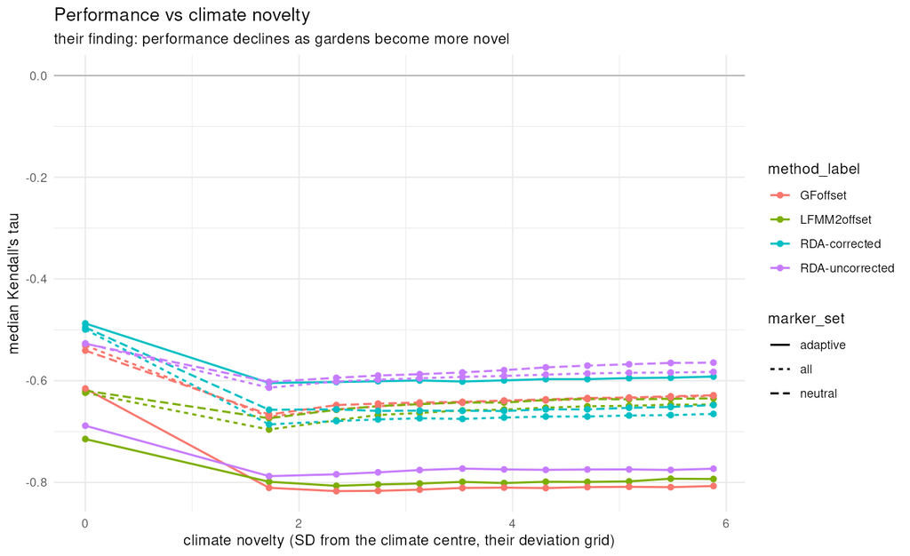

**Гипотеза «эффекта пола» проверена и отвергнута.** Она предсказывала, что слабая tau при `dev = 0` объясняется малым разбросом offset между источниками. Измерено (`offset_cv`, медиана):

[output not shown]

Разброс offset **падает** с ростом новизны (0.44 → 0.14), а tau при этом **растёт**. Если бы дело было в поле, направление было бы обратным. Гипотеза не годится.

**Что, по-видимому, происходит на самом деле.** В крайних садах и приспособленность, и offset становятся почти монотонными функциями одной и той же величины — положения дема на климатическом градиенте: все демы одинаково далеки от экстремального оптимума, и порядок определяется тем, чей фенотип ближе к краю. Ранжирование там — **более лёгкая задача**, а не более точное предсказание. Абсолютная величина offset при этом ничего не говорит: tau измеряет только порядок.

**Что идёт в статью.** Только прочтение 2 и только в форме «падения производительности с климатической новизной на нашей выборке мы не воспроизводим». Утверждать обратное их результату нельзя: их кривая построена на всём депозите, и как именно формируется их базис для этой панели, из опубликованного кода мы не восстановили. Разбор различия базисов остаётся **открытым пунктом**, а не результатом этого журнала.

## 13. Ограничения этих тестов

**1. Фаза 1 — подвыборка садов.** 30 ландшафтных садов из 100 (каждый 3-й дем, регулярная решётка) плюс все 12 садов новизны. Их утверждение «производительность варьирует между садами внутри ландшафта» на подвыборке проверяется слабее, чем на полном наборе; остальные 70 садов досчитываются отдельно и добавляются в этот же журнал.

**2. RONA отсутствует**, поэтому «ни один метод не выигрывает везде» проверяется на 4 реализациях из 5.

**3. Два предиктора.** У MVP ровно два климатических предиктора; преимущество методов с композитными осями (RDA) на двух осях проявиться не может. Ограничение унаследовано от журналов 06–08 целиком.

**4. 14 реплик против их 4.85 млн оценок.** Наши реплики отобраны по силе структуры (журнал 04), их выборка — весь депозит. Совпадение или расхождение с их числами читается как «пайплайн на этих 14 репликах даёт то же, что их конвейер», а не как независимое подтверждение их выводов.

**5. Приспособленность мгновенная.** Ни переадаптации, ни миграции после трансплантации — как и у них.

## 14. Дополнение 2026-08-07: панель закрыта до 588/588, происхождение данных смешанное

**Что изменилось.** На момент первого рендера журнала было готово 465 из 588 садов (11 реплик из 14). Три реплики — `1231288`, `1231578`, `1232568` — не досчитались: клоновые дорожки создавались раньше, чем в базовом дереве достраивалась модель Gradient Forest для панели `neutral_all`, дорожки пытались переобучить её сами и убивались по памяти на лимите 24 ГБ. Это была не ошибка кода, а ошибка порядка запуска.

Сейчас **588/588 садов** (14 реплик × 42 сада), 16 464 ячейки метод × панель × сад, пропусков нет.

**Происхождение данных смешанное, и это существенно.** 11 реплик посчитаны прежним драйвером (`mvp_garden_run_par.sh`, 2 вызова Snakemake на сад, 84 на реплику), 3 — новым, после того как в пайплайн добавили измерение `{scenario}`: одна модель проецируется на все 42 сада за один вызов, а `rda_offset_corrected` стал отдельным зарегистрированным методом и считается в том же вызове, а не вторым проходом.

**Почему смесь допустима.** Перед перезапуском проведена побайтовая сверка на реплике `1232218`, для которой сохранены эталонные результаты старого драйвера:

| проверка | результат |
| --- | --- |
| один сад (7 панелей × 4 метода) | 28/28 побайтово идентичны |
| все 42 сада | **1176/1176 побайтово идентичны**, max abs diff 0.000e+00 |
| после оптимизации `predict()` в GF | повторно 1176/1176 побайтово идентичны |

То есть новый код воспроизводит старый не «в пределах точности», а буквально. Числа ниже в этом журнале от смешения происхождения не зависят.

**Стоимость (измеренная, не оценённая).** Старый драйвер: медиана 917 с на сад (n = 845 садов по логам), то есть ≈10.7 ч вычислений на реплику. Новый: 4164 с вычислений на реплику — **в 9.2 раза меньше**. Три оставшиеся реплики досчитаны за **14.8 мин на все три**. Критический путь теперь — `geometric_offset`, который переобучает LFMM2 на каждый сад, потому что `LEA::genetic.gap()` принимает env/new.env/pred.env одним вызовом и не даёт переиспользовать подгонку.

Ограничение 1 из раздела 13 (подвыборка садов) остаётся в силе: 30 ландшафтных садов из 100. Закрыты именно недостающие реплики, а не недостающие сады.